# Module 8 Group Assignment

Shawn Abdian, Lexie Brown, Jenna Swiecki, Carolina Trevino, Saeeda Zaman,Bryan Yang

2022-07-28

# Overview

This assignment is based upon the R code, RStudio notebook, and discussion in the live session for this module. It does, however, use different data, so please make note of that. We have included that data (which, again, is different from the in-class lecture), a data description sheet (which is different from the in-class lecture), and the in-class RMD file (which is the same as the in-class lecture). We recommend that you attend or watch the live session recording for this module before attempting this assignment.

NANSE would like to get a better sense of how its stores in different parts of the country behave. In particular, they wonder if they could organize their cities into groups based upon the sales history of the stores in those cities. That is, they would like to get a better understanding of the geographical sales patterns at the city level. Luckily, they have a data set that lists each city as an observation and multiple features for each city such as the average size of each store in that city, the proportion of weeks each store in that city has had above median profit for a week, the average proportion of the top 20 products that the stores sell, the average proportion of products sold in different velocity groups, and the average proportion of products sold on promotion. Your job is to use the two clustering algorithms we have learned to cluster these cities into similar groups.

While you can simply reuse most of the code from class without alteration, this is a new dataset and you do have to make a few adjustments. In particular, before you run both the K-means analysis and the DBSCAN analysis, read the new dataset (“city.rds”) in and call it `clustering_input1`. Next, create a new dataset called `clustering_input2` by removing the columns `city`, `region`, and `province` from `clustering_input1`. Finally, use the number 77 for each `set.seed(77)` function.

Suggestion: While you could just cut and paste the code used in the high engagement session for this module, we encourage you to write all of the code from scratch. This is a technique we often use when looking up and using new code we are borrowing from someone else.

## 1.0 - Load and Prep the Data

### Install/Load Packages and Read in Data

```r
library(tidyverse)
library(factoextra)
clustering_input1 <- read_rds("city.rds")

# prep data per instruction
clustering_input2 <- clustering_input1 %>%
  select(-city, -region, -province)

str(clustering_input2)
```

```
## tibble [257 x 18] (S3: tbl_df/tbl/data.frame)
##  $ size                       : num [1:257] 762 1031 394 902 853 ...
##  $ promo_units_per            : num [1:257] 0.412 0.309 0.34 0.373 0.377 ...
##  $ high_med_gp                : num [1:257] 0.631 1 0 0.981 0.604 ...
##  $ velocityA_units_per        : num [1:257] 0.62 0.594 0.688 0.608 0.63 ...
##  $ velocityB_units_per        : num [1:257] 0.216 0.227 0.209 0.233 0.221 ...
##  $ velocityC_units_per        : num [1:257] 0.0729 0.0903 0.0381 0.0761 0.0683 ...
##  $ velocityD_units_per        : num [1:257] 0.0772 0.079 0.0571 0.0715 0.0673 ...
##  $ velocityNEW_units_per      : num [1:257] 0.00346 0.00217 0.0027 0.00219 0.0048 ...
##  $ energy_units_per           : num [1:257] 0.14 0.17 0.16 0.17 0.176 ...
##  $ regularBars_units_per      : num [1:257] 0.0948 0.0683 0.1067 0.0664 0.0884 ...
##  $ gum_units_per              : num [1:257] 0.05 0.0296 0.0703 0.0404 0.064 ...
##  $ bagpegCandy_units_per      : num [1:257] 0.0436 0.0292 0.0223 0.0433 0.0364 ...
##  $ isotonics_units_per        : num [1:257] 0.0603 0.0529 0.1019 0.0635 0.0592 ...
##  $ singleServePotato_units_per: num [1:257] 0.0323 0.0443 0.0325 0.0313 0.0347 ...
##  $ takeHomePotato_units_per   : num [1:257] 0.0227 0.0221 0 0.0244 0.02 ...
##  $ kingBars_units_per         : num [1:257] 0.0412 0.04 0.0735 0.0352 0.0396 ...
##  $ flatWater_units_per        : num [1:257] 0.0985 0.1116 0.0885 0.1041 0.0884 ...
##  $ psd591Ml_units_per         : num [1:257] 0.0347 0.0509 0.057 0.0537 0.0287 ...
```

```r
summary(clustering_input2)
```

```
##       size        promo_units_per   high_med_gp     velocityA_units_per
##  Min.   : 297.0   Min.   :0.2198   Min.   :0.0000   Min.   :0.5129
##  1st Qu.: 679.2   1st Qu.:0.3355   1st Qu.:0.1154   1st Qu.:0.6189
##  Median : 782.5   Median :0.3688   Median :0.5504   Median :0.6378
##  Mean   : 758.0   Mean   :0.3678   Mean   :0.5399   Mean   :0.6412
##  3rd Qu.: 869.8   3rd Qu.:0.3954   3rd Qu.:0.9904   3rd Qu.:0.6638
##  Max.   :1119.0   Max.   :0.5541   Max.   :1.0000   Max.   :0.7470
##  velocityB_units_per velocityC_units_per velocityD_units_per
##  Min.   :0.1524      Min.   :0.02724     Min.   :0.03778
##  1st Qu.:0.1962      1st Qu.:0.06197     1st Qu.:0.06308
##  Median :0.2089      Median :0.06952     Median :0.06900
##  Mean   :0.2074      Mean   :0.06848     Mean   :0.07012
##  3rd Qu.:0.2189      3rd Qu.:0.07687     3rd Qu.:0.07685
##  Max.   :0.2491      Max.   :0.10014     Max.   :0.14839
##  velocityNEW_units_per energy_units_per  regularBars_units_per
##  Min.   :0.0009289     Min.   :0.08248   Min.   :0.04800
##  1st Qu.:0.0028859     1st Qu.:0.13755   1st Qu.:0.07187
##  Median :0.0039880     Median :0.16549   Median :0.08104
##  Mean   :0.0040320     Mean   :0.17033   Mean   :0.08247
##  3rd Qu.:0.0049742     3rd Qu.:0.19413   3rd Qu.:0.09102
##  Max.   :0.0148708     Max.   :0.31297   Max.   :0.16850
##  gum_units_per     bagpegCandy_units_per isotonics_units_per
##  Min.   :0.02019   Min.   :0.00000       Min.   :0.02492
##  1st Qu.:0.04470   1st Qu.:0.02524       1st Qu.:0.05490
##  Median :0.05877   Median :0.03011       Median :0.06035
##  Mean   :0.06004   Mean   :0.02991       Mean   :0.06072
##  3rd Qu.:0.07372   3rd Qu.:0.03520       3rd Qu.:0.06640
##  Max.   :0.15876   Max.   :0.05245       Max.   :0.10191
##  singleServePotato_units_per takeHomePotato_units_per kingBars_units_per
##  Min.   :0.01384             Min.   :0.00000          Min.   :0.01114
##  1st Qu.:0.03122             1st Qu.:0.01809          1st Qu.:0.03272
##  Median :0.03592             Median :0.02250          Median :0.03946
##  Mean   :0.03721             Mean   :0.02321          Mean   :0.03939
##  3rd Qu.:0.04157             3rd Qu.:0.02790          3rd Qu.:0.04494
##  Max.   :0.08420             Max.   :0.05575          Max.   :0.08355
##  flatWater_units_per psd591Ml_units_per
##  Min.   :0.04537     Min.   :0.01577
##  1st Qu.:0.08269     1st Qu.:0.03275
##  Median :0.09457     Median :0.04133
##  Mean   :0.09726     Mean   :0.04204
##  3rd Qu.:0.11114     3rd Qu.:0.05049
##  Max.   :0.16152     Max.   :0.08940
```

### Z-score Standardization

```r
clutering_input2 <- as.data.frame(scale(clustering_input2))
```

## 2.0 - Picking k

### Find a suitable k using two different methods

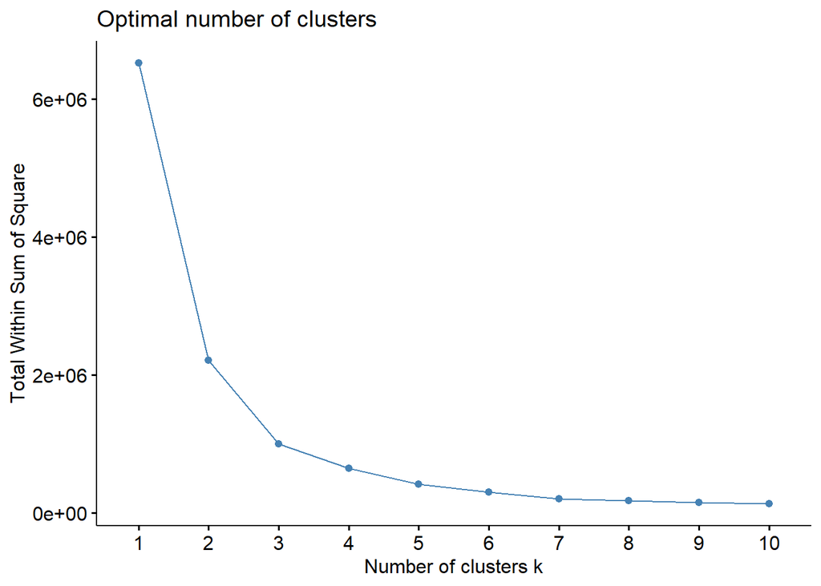

```r
# Within-cluster sum of square method
set.seed(77)
factoextra::fviz_nbclust(clustering_input2, kmeans, method = "wss")
```

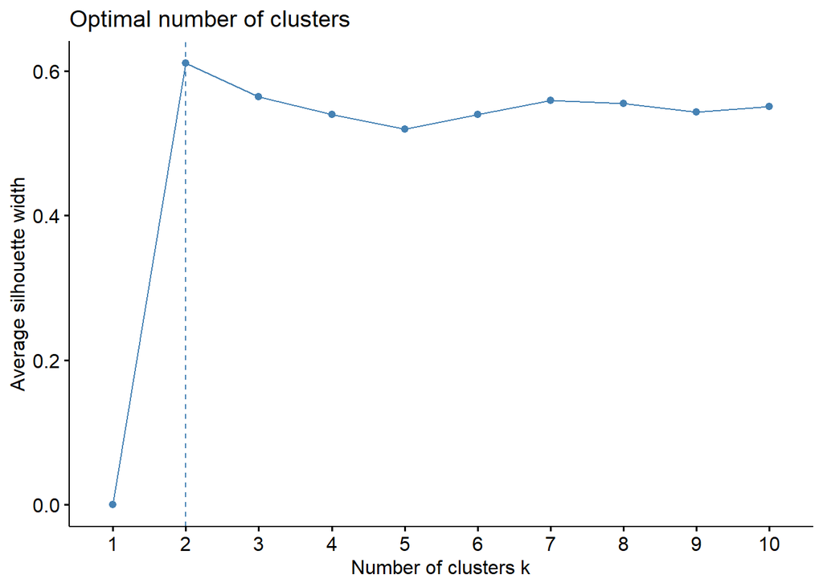

```r
set.seed(77)
factoextra::fviz_nbclust(clustering_input2, kmeans, method = "silhouette")
```

## 3.0 - Run and Evaluate k-means

### Run the model

```r
set.seed(77)
clusters <- kmeans(clustering_input2, centers=4, iter.max=3, nstart=3)
```

### Check the size of the k clusters

```r
clusters$size
```

```
## [1] 66 96 36 59
```

### A matrix indicating the mean values for each feature and cluster combination

```r
clusters$centers
```

```
##       size promo_units_per high_med_gp velocityA_units_per velocityB_units_per
## 1 930.4000       0.3517431  0.93082718           0.6173855           0.2121624
## 2 804.3892       0.3713706  0.58634493           0.6341364           0.2109069
## 3 455.0532       0.3712948  0.03169516           0.6816958           0.1946013
## 4 674.5424       0.3777029  0.33714382           0.6546801           0.2040193
##   velocityC_units_per velocityD_units_per velocityNEW_units_per
## 1          0.07781560          0.07778046           0.004337085
## 2          0.07173103          0.06983138           0.004385557
## 3          0.05108256          0.06444423           0.003122266
## 4          0.06334909          0.06547998           0.003670439
##   energy_units_per regularBars_units_per gum_units_per bagpegCandy_units_per
## 1        0.1616131            0.07670348    0.04975255            0.03357462
## 2        0.1721752            0.08197128    0.05858926            0.03219718
## 3        0.1832593            0.08984656    0.07594548            0.02033457
## 4        0.1692097            0.08521794    0.06421156            0.02792063
##   isotonics_units_per singleServePotato_units_per takeHomePotato_units_per
## 1          0.05897825                  0.03888808               0.03030012
## 2          0.05966140                  0.03638228               0.02399868
## 3          0.06352357                  0.03838772               0.01313059
## 4          0.06269896                  0.03597991               0.02014275
##   kingBars_units_per flatWater_units_per psd591Ml_units_per
## 1         0.03590073          0.09994470         0.04123654
## 2         0.03712273          0.09433881         0.04226340
## 3         0.04888429          0.09958063         0.04161855
## 4         0.04116786          0.09758223         0.04283072
```

### Visualize the clustering

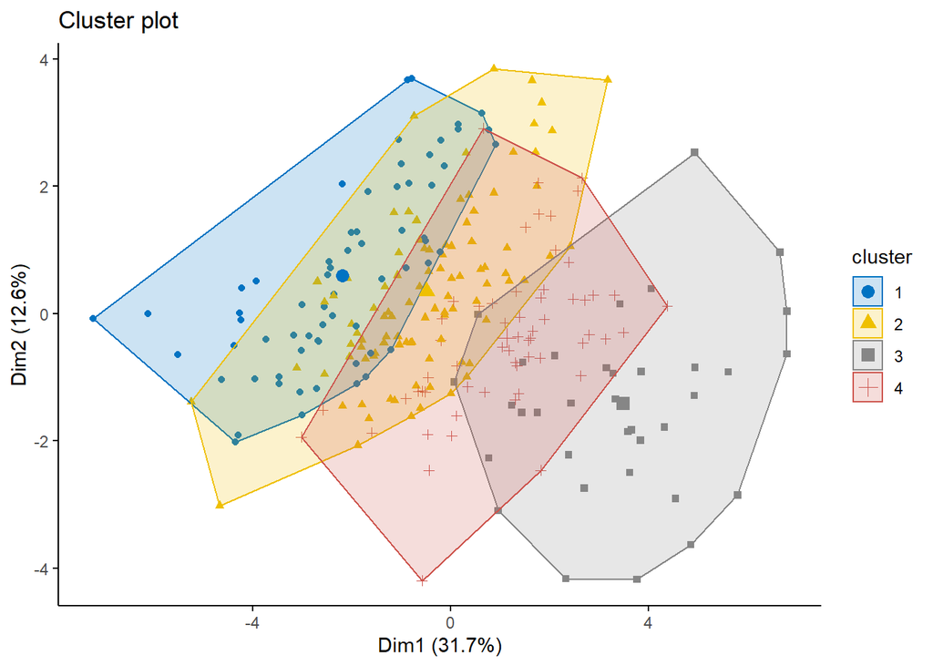

```r
fviz_cluster(clusters, clustering_input2, geom="point", show.clust.cent=T, palette="jco", ggtheme=theme_classic())
```

1. (2 points) How many clusters do you want to use for the K-means algorithm for this data? Play around a bit to make your decision. Justify your answer with evidence from your analysis. Specifically, in a few sentences discuss the following:
- 1.a. results from the “wss” and the “silhouette” methods of finding the optimal number of clusters,

**For Within Sum of Square (wss) method, anything between 3-5 seems reasonable since we want to pick a k at the “knee/elbow” such that moving to the next higher k does not decrease wss much.**

**Silhouette method measures and plots the quality of a clustering for a given value of k. It ultimately determines how well matched each object is to its own cluster compared to other clusters. Hence, the highest value is ideal. Therefore, anything between 2-10 seems reasonable. However, 2 is the highest.**

- 1.b. the size of clusters, and the two-dimensional cluster plot. There is no right answer here, but clearly defend your responses.

## 4.0 - Put Clusters back into the dataset and investigate individual stores

### Add clusters to the original, un-standardized dataset and add labels

```r
clustering_input1$cluster <- clusters$cluster

clustering_input1 <- clustering_input1 %>%
      mutate(
              cluster_labels = case_when
                (
                  cluster==1 ~ 'LR_Size_HI_GP',
                  cluster==2 ~ 'MD_Size_MD_GP',
                  cluster==3 ~ 'SM_Size_LO_GP',
                  cluster==4 ~ 'MD-SD_Size_MD-LO_GP'
                )
             )

clustering_input1 <- relocate(clustering_input1, cluster,  cluster_labels, .after = city)

slice_sample(clustering_input1, n=15)
```

```
## # A tibble: 15 x 23
##    city             cluster cluster_labels province region  size promo_units_per
##    <chr>              <int> <chr>          <chr>    <chr>  <dbl>           <dbl>
##  1 MARKHAM                2 MD_Size_MD_GP  ON       ONTAR~  746.           0.346
##  2 COURTICE               3 SM_Size_LO_GP  ON       ONTAR~  561            0.554
##  3 NORTH YORK             4 MD-SD_Size_MD~ ON       ONTAR~  711.           0.338
##  4 KINGSTON               2 MD_Size_MD_GP  ON       ONTAR~  816.           0.426
##  5 TROIS-PISTOLES         2 MD_Size_MD_GP  QC       QUEBEC  851            0.356
##  6 BEAVERTON              3 SM_Size_LO_GP  ON       ONTAR~  532            0.400
##  7 THORNTON               3 SM_Size_LO_GP  ON       ONTAR~  489            0.406
##  8 DELSON                 4 MD-SD_Size_MD~ QC       QUEBEC  731            0.382
##  9 LANGLEY                2 MD_Size_MD_GP  BC       WEST    756.           0.385
## 10 INGERSOLL              3 SM_Size_LO_GP  ON       ONTAR~  410            0.354
## 11 LETHBRIDGE             1 LR_Size_HI_GP  AB       WEST    870.           0.350
## 12 MAPLE RIDGE            4 MD-SD_Size_MD~ BC       WEST    737.           0.414
## 13 ROCKY MOUNTAIN ~       2 MD_Size_MD_GP  AB       WEST    843            0.324
## 14 MONTRÃ‰AL NORD         2 MD_Size_MD_GP  QC       QUEBEC  813            0.384
## 15 REGINA                 1 LR_Size_HI_GP  SK       WEST    871            0.284
## # ... with 16 more variables: high_med_gp <dbl>, velocityA_units_per <dbl>,
## #   velocityB_units_per <dbl>, velocityC_units_per <dbl>,
## #   velocityD_units_per <dbl>, velocityNEW_units_per <dbl>,
## #   energy_units_per <dbl>, regularBars_units_per <dbl>, gum_units_per <dbl>,
## #   bagpegCandy_units_per <dbl>, isotonics_units_per <dbl>,
## #   singleServePotato_units_per <dbl>, takeHomePotato_units_per <dbl>,
## #   kingBars_units_per <dbl>, flatWater_units_per <dbl>, ...
```

**Analyzing the cluster centers, all the columns have similar values across the cluster 1-4 other than ‘size’ and ‘high_med_gp’. Based on the difference of these two fields, we came up with some names of the clusters.**  
**We named cluster 1 ‘LR_Size_HI_GP’, because it is the largest and has the highest median gross profit.**  
**We named cluster 2 ‘MD_Size_MD_GP’, because it has the second highest size and median gross profit.**  
**We named cluster 3 ‘SM_Size_LO_GP’, because it is the smallest with low median gross profit.**  
**We named cluster 4 ‘MD-SD_Size_MD-LO_GP’, because it is in between cluster 2 & 3 in terms of size and median gross profit.**  
**After naming the clusters, we placed those cluster names into the ‘clustering_input1’ dataset in the code above.**

- 2.b.Which number of cluster groups together the cities that are the largest and most profitable?

**Cluster 1 stores are the largest and most profitable.**

- 2.c.In two or three sentences, provide one recommendation to NANSE based upon this analysis.

**All else is equal for four clusters other than this data, there seems to be a relationship between size of the stores and gross profits in general. NANSE should further look into what the cluster 1 stores are doing different from cluster 3.**

3. (2 points) After adding your cluster names to `clustering_input1` above in 2a, look at the dataset and use two or three sentences to describe what you learn about the cities of Trenton and Parry Sound. We did not standardize the data in `clustering_input1`, so this data is easier to interpret following the data description sheet.

**Based on the data in ‘clustering_input1’, Parry Sound seems to be in the cluster 1 and Trenton cluster 3. This means that Parry Sound is one of the large size stores with above high median gross profit while Trenton is one of the small size stores with below high median gross profit. We can prove it by observing the data below. The size for Parry Sound is 955 and high_med_gp 1 and Trenton 351 & 0 for the same columns. It’s also notable that other fields seem to vary more between two cities than respective cluster’s fields average each city belongs to.**

```r
sample <- filter(clustering_input1, city=="PARRY SOUND"| city=="TRENTON")
sample
```

```
## # A tibble: 2 x 23
##   city  cluster cluster_labels province region  size promo_units_per high_med_gp
##   <chr>   <int> <chr>          <chr>    <chr>  <dbl>           <dbl>       <dbl>
## 1 PARR~       1 LR_Size_HI_GP  ON       ONTAR~   955           0.273           1
## 2 TREN~       3 SM_Size_LO_GP  ON       ONTAR~   351           0.448           0
## # ... with 15 more variables: velocityA_units_per <dbl>,
## #   velocityB_units_per <dbl>, velocityC_units_per <dbl>,
## #   velocityD_units_per <dbl>, velocityNEW_units_per <dbl>,
## #   energy_units_per <dbl>, regularBars_units_per <dbl>, gum_units_per <dbl>,
## #   bagpegCandy_units_per <dbl>, isotonics_units_per <dbl>,
## #   singleServePotato_units_per <dbl>, takeHomePotato_units_per <dbl>,
## #   kingBars_units_per <dbl>, flatWater_units_per <dbl>, ...
```

## 5.0 DBSCAN

### Load DBSCAN package & Reset Data

```r
library(dbscan)

clustering_input1 <- read_rds("city.rds")

# prep data per instruction
clustering_input2 <- clustering_input1 %>%
  select(-city, -region, -province)
```

### Standardize the data using z-score standardization.

```r
clustering_input2 <- as.data.frame(scale(clustering_input2))
```

### Using `dbscan::knndistplot()` to find a suitable epsilon.

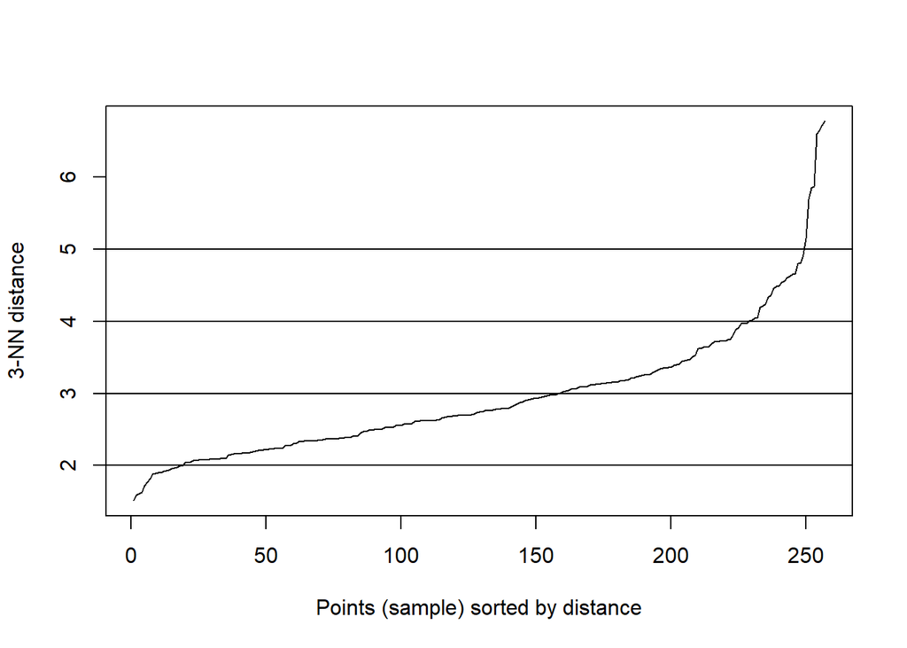

```r
dbscan::kNNdistplot(clustering_input2, k=3)

# Drawing some lines to find the "elbow"
abline(h = c(2, 3, 4, 5))
```

### Using the minPts and epsilon from above to run the DBSCAN algorithm

```r
set.seed(77)
clusters_db <- dbscan::dbscan(clustering_input2, eps=5, minPts=4)
```

### Using the `table()` function to print the size of the clusters.

```r
table(clusters_db$cluster)
```

```
##
##   0   1
##   4 253
```

## 6.0 - Visualize the Clusters

### Visualize the Clusters

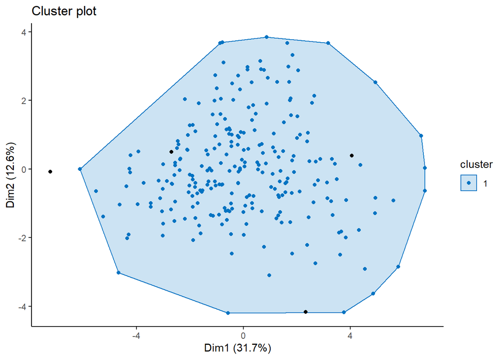

```r
fviz_cluster(clusters_db, clustering_input2, geom="point", show.clust.cent=F, palette="jco", ggtheme=theme_classic())
```

4. (1 points) Run the DBSCAN algorithm using epsilon = 5 and minPts = 4. Print the size of the clusters that this creates. How many clusters are there and how many cities are in each cluster?

**Based on the code and output above, there is one cluster with 253 cities. Other outlier cities are 4.**

5. (2 points) How does your solution using K-means compare to that using DBSCAN? Specifically, using about three sentences answer the following:
- 5.a.Which is more helpful and why for this dataset? Which method would you suggest that the management of NANSE use and why?

**K-means provided more useful information for this dataset because dataset was more clustered together. K-means was able to parse the data with fixed cluster size where as the dataset was too clustered for DBSCAN. If the dataset had more divided and clustered, DBSCAN could’ve been a great choice.**

- 5.b.How do the methods deal with outliers differently in this data?  
  **Although k-mean showed a meaningful insight for this dataset, it still included every single observation in the dataset. It was hard to figure out which observations were outliers. DBSCAN helps us with figuring out the outliers from the rest of the dataset as shown on the plot above.**